# Prediction of academic achievement in adolescents from teacher reports of inattention in childhood - a pattern classification study

AJ Lundervold, T Bø, A Lundervold

```r
~GitHub/inattention-population/code/inattention-populationsample-mlr.Rmd
```

This is an [R Markdown](http://rmarkdown.rstudio.com) Notebook. When you execute code within the notebook, the results appear beneath the code. Try executing this chunk by clicking the *Run* button within the chunk or by placing your cursor inside it and pressing *Cmd+Shift+Enter*. Add a new chunk by clicking the *Insert Chunk* button on the toolbar or by pressing *Cmd+Option+I*. When you save the notebook, an HTML file containing the code and output will be saved alongside it (click the *Preview* button or press *Cmd+Shift+K* to preview the HTML file).

Organization of the data and the analysis:

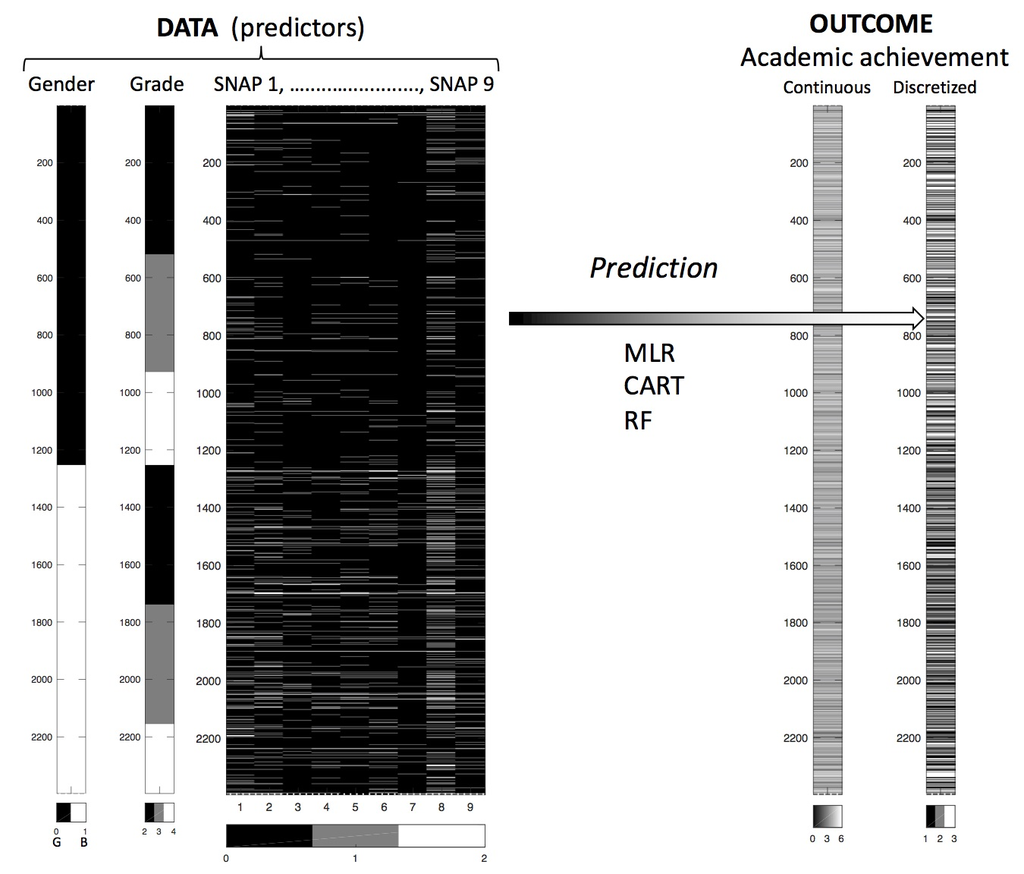

### Data preparation

Builds on processing in *~GitHub/inattention-population/code/inattention-populationsample-data-prep.Rmd*

```r
D3 <- read.csv(file = "../data/inattention_nomiss_2397x12_snap_is_0_1_2.csv")
C <- read.csv(file = "../data/inattention_nomiss_2397x12_snap_is_0_1_2_outcome_is_L_M_H.csv")
D <- read.csv(file = "../data/inattention_nomiss_2397x12_snap_is_N_S_C_outcome_is_L_M_H.csv")
E <- read.csv(file = "../data/inattention_nomiss_2397x12_snap_is_0_1_2_outcome_is_0_1_2.csv")
str(D3)
```

```
'data.frame':   2397 obs. of  12 variables:
 $ gender: int  1 1 1 1 1 1 1 1 1 1 ...
 $ grade : int  2 2 2 2 2 2 2 2 2 2 ...
 $ snap1 : int  1 1 1 1 1 1 1 1 1 1 ...
 $ snap2 : int  1 1 1 1 1 1 1 1 1 1 ...
 $ snap3 : int  1 2 1 1 1 1 1 1 1 1 ...
 $ snap4 : int  1 1 1 1 1 1 1 1 1 1 ...
 $ snap5 : int  1 1 1 1 1 1 1 1 1 1 ...
 $ snap6 : int  1 1 1 1 1 1 1 1 1 1 ...
 $ snap7 : int  1 1 1 1 1 1 1 1 1 1 ...
 $ snap8 : int  1 1 1 1 1 1 1 1 2 1 ...
 $ snap9 : int  1 1 1 1 1 1 1 1 1 1 ...
 $ ave   : num  4.67 3.67 4.14 4.11 4.3 ...
```

```r
head(D3)
```

|  | gender | grade | snap1 | snap2 | snap3 | snap4 | snap5 | snap6 | snap7 | snap8 | snap9 | ave |
| --- | --- | --- | --- | --- | --- | --- | --- | --- | --- | --- | --- | --- |
| 1 | 1 | 2 | 1 | 1 | 1 | 1 | 1 | 1 | 1 | 1 | 1 | 4.666667 |
| 2 | 1 | 2 | 1 | 1 | 2 | 1 | 1 | 1 | 1 | 1 | 1 | 3.666667 |
| 3 | 1 | 2 | 1 | 1 | 1 | 1 | 1 | 1 | 1 | 1 | 1 | 4.142857 |
| 4 | 1 | 2 | 1 | 1 | 1 | 1 | 1 | 1 | 1 | 1 | 1 | 4.111111 |
| 5 | 1 | 2 | 1 | 1 | 1 | 1 | 1 | 1 | 1 | 1 | 1 | 4.300000 |
| 6 | 1 | 2 | 1 | 1 | 1 | 1 | 1 | 1 | 1 | 1 | 1 | 3.888889 |

```r
str(C)
```

```
'data.frame':   2397 obs. of  12 variables:
 $ gender    : int  1 1 1 1 1 1 1 1 1 1 ...
 $ grade     : int  2 2 2 2 2 2 2 2 2 2 ...
 $ snap1     : int  1 1 1 1 1 1 1 1 1 1 ...
 $ snap2     : int  1 1 1 1 1 1 1 1 1 1 ...
 $ snap3     : int  1 2 1 1 1 1 1 1 1 1 ...
 $ snap4     : int  1 1 1 1 1 1 1 1 1 1 ...
 $ snap5     : int  1 1 1 1 1 1 1 1 1 1 ...
 $ snap6     : int  1 1 1 1 1 1 1 1 1 1 ...
 $ snap7     : int  1 1 1 1 1 1 1 1 1 1 ...
 $ snap8     : int  1 1 1 1 1 1 1 1 2 1 ...
 $ snap9     : int  1 1 1 1 1 1 1 1 1 1 ...
 $ averBinned: Factor w/ 3 levels "H","L","M": 1 2 3 3 3 3 2 3 1 3 ...
```

```r
head(C)
```

|  | gender | grade | snap1 | snap2 | snap3 | snap4 | snap5 | snap6 | snap7 | snap8 | snap9 | averBinned |
| --- | --- | --- | --- | --- | --- | --- | --- | --- | --- | --- | --- | --- |
| 1 | 1 | 2 | 1 | 1 | 1 | 1 | 1 | 1 | 1 | 1 | 1 | H |
| 2 | 1 | 2 | 1 | 1 | 2 | 1 | 1 | 1 | 1 | 1 | 1 | L |
| 3 | 1 | 2 | 1 | 1 | 1 | 1 | 1 | 1 | 1 | 1 | 1 | M |
| 4 | 1 | 2 | 1 | 1 | 1 | 1 | 1 | 1 | 1 | 1 | 1 | M |
| 5 | 1 | 2 | 1 | 1 | 1 | 1 | 1 | 1 | 1 | 1 | 1 | M |
| 6 | 1 | 2 | 1 | 1 | 1 | 1 | 1 | 1 | 1 | 1 | 1 | M |

```r
str(D)
```

```
'data.frame':   2397 obs. of  12 variables:
 $ gender    : Factor w/ 2 levels "B","G": 1 1 1 1 1 1 1 1 1 1 ...
 $ grade     : Factor w/ 3 levels "2nd","3rd","4th": 1 1 1 1 1 1 1 1 1 1 ...
 $ snap1     : Factor w/ 3 levels "C","N","S": 3 3 3 3 3 3 3 3 3 3 ...
 $ snap2     : Factor w/ 3 levels "C","N","S": 3 3 3 3 3 3 3 3 3 3 ...
 $ snap3     : Factor w/ 3 levels "C","N","S": 3 1 3 3 3 3 3 3 3 3 ...
 $ snap4     : Factor w/ 3 levels "C","N","S": 3 3 3 3 3 3 3 3 3 3 ...
 $ snap5     : Factor w/ 3 levels "C","N","S": 3 3 3 3 3 3 3 3 3 3 ...
 $ snap6     : Factor w/ 3 levels "C","N","S": 3 3 3 3 3 3 3 3 3 3 ...
 $ snap7     : Factor w/ 3 levels "C","N","S": 3 3 3 3 3 3 3 3 3 3 ...
 $ snap8     : Factor w/ 3 levels "C","N","S": 3 3 3 3 3 3 3 3 1 3 ...
 $ snap9     : Factor w/ 3 levels "C","N","S": 3 3 3 3 3 3 3 3 3 3 ...
 $ averBinned: Factor w/ 3 levels "H","L","M": 1 2 3 3 3 3 2 3 1 3 ...
```

```r
head(D)
```

|  | gender | grade | snap1 | snap2 | snap3 | snap4 | snap5 | snap6 | snap7 | snap8 | snap9 | averBinned |
| --- | --- | --- | --- | --- | --- | --- | --- | --- | --- | --- | --- | --- |
| 1 | B | 2nd | S | S | S | S | S | S | S | S | S | H |
| 2 | B | 2nd | S | S | C | S | S | S | S | S | S | L |
| 3 | B | 2nd | S | S | S | S | S | S | S | S | S | M |
| 4 | B | 2nd | S | S | S | S | S | S | S | S | S | M |
| 5 | B | 2nd | S | S | S | S | S | S | S | S | S | M |
| 6 | B | 2nd | S | S | S | S | S | S | S | S | S | M |

```r
str(E)
```

```
'data.frame':   2397 obs. of  12 variables:
 $ gender    : int  1 1 1 1 1 1 1 1 1 1 ...
 $ grade     : int  2 2 2 2 2 2 2 2 2 2 ...
 $ snap1     : int  1 1 1 1 1 1 1 1 1 1 ...
 $ snap2     : int  1 1 1 1 1 1 1 1 1 1 ...
 $ snap3     : int  1 2 1 1 1 1 1 1 1 1 ...
 $ snap4     : int  1 1 1 1 1 1 1 1 1 1 ...
 $ snap5     : int  1 1 1 1 1 1 1 1 1 1 ...
 $ snap6     : int  1 1 1 1 1 1 1 1 1 1 ...
 $ snap7     : int  1 1 1 1 1 1 1 1 1 1 ...
 $ snap8     : int  1 1 1 1 1 1 1 1 2 1 ...
 $ snap9     : int  1 1 1 1 1 1 1 1 1 1 ...
 $ averBinned: int  2 0 1 1 1 1 0 1 2 1 ...
```

```r
head(E)
```

|  | gender | grade | snap1 | snap2 | snap3 | snap4 | snap5 | snap6 | snap7 | snap8 | snap9 | averBinned |
| --- | --- | --- | --- | --- | --- | --- | --- | --- | --- | --- | --- | --- |
| 1 | 1 | 2 | 1 | 1 | 1 | 1 | 1 | 1 | 1 | 1 | 1 | 2 |
| 2 | 1 | 2 | 1 | 1 | 2 | 1 | 1 | 1 | 1 | 1 | 1 | 0 |
| 3 | 1 | 2 | 1 | 1 | 1 | 1 | 1 | 1 | 1 | 1 | 1 | 1 |
| 4 | 1 | 2 | 1 | 1 | 1 | 1 | 1 | 1 | 1 | 1 | 1 | 1 |
| 5 | 1 | 2 | 1 | 1 | 1 | 1 | 1 | 1 | 1 | 1 | 1 | 1 |
| 6 | 1 | 2 | 1 | 1 | 1 | 1 | 1 | 1 | 1 | 1 | 1 | 1 |

```r
# Using numerical scores in 'inattention_nomiss_2397x12_snap_is_0_1_2_outcome_is_0_1_2.csv'
E$averBinnedF = as.factor(E$averBinned)  # To perform clasification and not regression
E <- subset(E, select = -c(averBinned))
head(E)
```

|  | gender | grade | snap1 | snap2 | snap3 | snap4 | snap5 | snap6 | snap7 | snap8 | snap9 | averBinnedF |
| --- | --- | --- | --- | --- | --- | --- | --- | --- | --- | --- | --- | --- |
| 1 | 1 | 2 | 1 | 1 | 1 | 1 | 1 | 1 | 1 | 1 | 1 | 2 |
| 2 | 1 | 2 | 1 | 1 | 2 | 1 | 1 | 1 | 1 | 1 | 1 | 0 |
| 3 | 1 | 2 | 1 | 1 | 1 | 1 | 1 | 1 | 1 | 1 | 1 | 1 |
| 4 | 1 | 2 | 1 | 1 | 1 | 1 | 1 | 1 | 1 | 1 | 1 | 1 |
| 5 | 1 | 2 | 1 | 1 | 1 | 1 | 1 | 1 | 1 | 1 | 1 | 1 |
| 6 | 1 | 2 | 1 | 1 | 1 | 1 | 1 | 1 | 1 | 1 | 1 | 1 |

### More on the SNAP data

Use Likert scale with three levels (not collapsing to two)

APROPOS: - should actually be five (https://en.wikipedia.org/wiki/Likert_scale) When responding to a Likert questionnaire item, respondents specify their level of agreement or disagreement on a symmetric agree-disagree scale for a series of statements. Thus, the range captures the intensity of their feelings for a given item. The format of a typical five-level Likert item, for example, could be:

- 1 Strongly disagree
- 2 Disagree
- 3 Neither agree nor disagree
- 4 Agree
- 5 Strongly agree

Likert scaling is a bipolar scaling method, measuring either positive or negative response to a statement.

```r
data <- as.data.frame(E)
# for(i in 1:9){
#  cmd = sprintf("data$snap%d <- EE$snap%d", i, i)
#  # print(cmd)
#  eval(parse(text=cmd))
#}
```

```r
# Check that no datapoint is missing
apply(data,2,function(x) sum(is.na(x)))
```

```
     gender       grade       snap1       snap2       snap3       snap4       snap5       snap6
          0           0           0           0           0           0           0           0
      snap7       snap8       snap9 averBinnedF
          0           0           0           0
```

```r
# SIDESTEP: Randomly splitting the data into a train and a test set
index <- sample(1:nrow(data),round(0.75*nrow(data)))
train <- data[index,]
test <- data[-index,]
# Fit a linear regression model and test it on the test set.
# lm.fit <- glm(averBinned ~ ., data=train)
# summary(lm.fit)
```

#### Using *multinom* in the NNET package

```r
# Before running our model. We then choose the level of our outcome that we wish
# to use as our baseline and specify this in the relevel function.
# Then, we run our model using multinom.
library(nnet)
data$AverageMarksLevel3 <- relevel(factor(data$averBinnedF), ref = "2")   # ref = "high"
multinom.E.1 <- multinom(AverageMarksLevel3 ~
                   gender+grade +
                   snap1+snap2+snap3+snap4+snap5+snap6+snap7+snap8+snap9,
                   data = data)
multinom.E.1
```

```
Call:
multinom(formula = AverageMarksLevel3 ~ gender + grade + snap1 +
    snap2 + snap3 + snap4 + snap5 + snap6 + snap7 + snap8 + snap9,
    data = data)

Coefficients:
  (Intercept)     gender       grade     snap1     snap2     snap3        snap4     snap5     snap6
0   -3.576269 -0.6279154  0.11553779 0.3199481 0.4878501 0.2741296  0.492944142 0.1919766 0.6182381
1   -1.250475 -0.3316787 -0.05074185 0.3166351 0.1794342 0.1132252 -0.005354886 0.2016094 0.1536873
      snap7     snap8     snap9
0 0.3621588 0.2414844 0.3312041
1 0.1969053 0.1413410 0.2231926

Residual Deviance: 5095.539
AIC: 5143.539
```

```r
summary(multinom.E.1)
```

```
Call:
multinom(formula = AverageMarksLevel3 ~ gender + grade + snap1 +
    snap2 + snap3 + snap4 + snap5 + snap6 + snap7 + snap8 + snap9,
    data = data)

Coefficients:
  (Intercept)     gender       grade     snap1     snap2     snap3        snap4     snap5     snap6
0   -3.576269 -0.6279154  0.11553779 0.3199481 0.4878501 0.2741296  0.492944142 0.1919766 0.6182381
1   -1.250475 -0.3316787 -0.05074185 0.3166351 0.1794342 0.1132252 -0.005354886 0.2016094 0.1536873
      snap7     snap8     snap9
0 0.3621588 0.2414844 0.3312041
1 0.1969053 0.1413410 0.2231926

Std. Errors:
  (Intercept)    gender      grade     snap1     snap2     snap3     snap4     snap5     snap6     snap7
0   0.5182377 0.1064526 0.06602545 0.1648059 0.1901665 0.2167935 0.2439379 0.2222724 0.2195758 0.3329024
1   0.5251404 0.1026967 0.06401255 0.1666322 0.1988691 0.2217002 0.2554146 0.2286107 0.2320391 0.3376681
      snap8     snap9
0 0.1242812 0.1888648
1 0.1262303 0.1904451

Residual Deviance: 5095.539
AIC: 5143.539
```

```r
z <- summary(multinom.E.1)$coefficients/summary(multinom.E.1)$standard.errors
# 2-tailed z test
p <- (1 - pnorm(abs(z), 0, 1)) * 2
p
```

```
   (Intercept)       gender      grade      snap1      snap2     snap3      snap4     snap5       snap6
0 5.170087e-12 3.667225e-09 0.08013596 0.05221432 0.01030616 0.2060601 0.04330279 0.3877530 0.004868599
1 1.725538e-02 1.239233e-03 0.42796088 0.05740647 0.36691197 0.6095522 0.98327320 0.3778365 0.507757362
      snap7      snap8      snap9
0 0.2766469 0.05201026 0.07948933
1 0.5598039 0.26283831 0.24121610
```

```r
## extract the coefficients from the model and exponentiate
c <- exp(coef(multinom.E.1))
# You can also use predicted probabilities to help you understand the model.
# Calculate predicted probabilities for each of the outcome levels using
# the fitted function. We can start by generating the predicted probabilities
# for the observations in our dataset and viewing the first few rows
head(pp <- fitted(multinom.E.1))
```

```
          2        0         1
1 0.4219384 0.219573 0.3584886
2 0.3793635 0.259680 0.3609566
3 0.4219384 0.219573 0.3584886
4 0.4219384 0.219573 0.3584886
5 0.4219384 0.219573 0.3584886
6 0.4219384 0.219573 0.3584886
```

```r
# Fore easy input to LaTeX:
library(stargazer)
stargazer(multinom.E.1)
```

```
the condition has length > 1 and only the first element will be used
```

```
% Table created by stargazer v.5.2 by Marek Hlavac, Harvard University. E-mail: hlavac at fas.harvard.edu
% Date and time: Fri, Dec 09, 2016 - 18:32:50
\begin{table}[!htbp] \centering
  \caption{}
  \label{}
\begin{tabular}{@{\extracolsep{5pt}}lcc}
\\[-1.8ex]\hline
\hline \\[-1.8ex]
 & \multicolumn{2}{c}{\textit{Dependent variable:}} \\
\cline{2-3}
\\[-1.8ex] & 0 & 1 \\
\\[-1.8ex] & (1) & (2)\\
\hline \\[-1.8ex]
 gender & $-$0.628$^{***}$ & $-$0.332$^{***}$ \\
  & (0.106) & (0.103) \\
  & & \\
 grade & 0.116$^{*}$ & $-$0.051 \\
  & (0.066) & (0.064) \\
  & & \\
 snap1 & 0.320$^{*}$ & 0.317$^{*}$ \\
  & (0.165) & (0.167) \\
  & & \\
 snap2 & 0.488$^{**}$ & 0.179 \\
  & (0.190) & (0.199) \\
  & & \\
 snap3 & 0.274 & 0.113 \\
  & (0.217) & (0.222) \\
  & & \\
 snap4 & 0.493$^{**}$ & $-$0.005 \\
  & (0.244) & (0.255) \\
  & & \\
 snap5 & 0.192 & 0.202 \\
  & (0.222) & (0.229) \\
  & & \\
 snap6 & 0.618$^{***}$ & 0.154 \\
  & (0.220) & (0.232) \\
  & & \\
 snap7 & 0.362 & 0.197 \\
  & (0.333) & (0.338) \\
  & & \\
 snap8 & 0.241$^{*}$ & 0.141 \\
  & (0.124) & (0.126) \\
  & & \\
 snap9 & 0.331$^{*}$ & 0.223 \\
  & (0.189) & (0.190) \\
  & & \\
 Constant & $-$3.576$^{***}$ & $-$1.250$^{**}$ \\
  & (0.518) & (0.525) \\
  & & \\
\hline \\[-1.8ex]
Akaike Inf. Crit. & 5,143.539 & 5,143.539 \\
\hline
\hline \\[-1.8ex]
\textit{Note:}  & \multicolumn{2}{r}{$^{*}$p$<$0.1; $^{**}$p$<$0.05; $^{***}$p$<$0.01} \\
\end{tabular}
\end{table}
```

```r
stargazer(p)
```

```
% Table created by stargazer v.5.2 by Marek Hlavac, Harvard University. E-mail: hlavac at fas.harvard.edu
% Date and time: Fri, Dec 09, 2016 - 18:32:50
\begin{table}[!htbp] \centering
  \caption{}
  \label{}
\begin{tabular}{@{\extracolsep{5pt}} ccccccccccccc}
\\[-1.8ex]\hline
\hline \\[-1.8ex]
 & (Intercept) & gender & grade & snap1 & snap2 & snap3 & snap4 & snap5 & snap6 & snap7 & snap8 & snap9 \\
\hline \\[-1.8ex]
0 & $0$ & $0$ & $0.080$ & $0.052$ & $0.010$ & $0.206$ & $0.043$ & $0.388$ & $0.005$ & $0.277$ & $0.052$ & $0.079$ \\
1 & $0.017$ & $0.001$ & $0.428$ & $0.057$ & $0.367$ & $0.610$ & $0.983$ & $0.378$ & $0.508$ & $0.560$ & $0.263$ & $0.241$ \\
\hline \\[-1.8ex]
\end{tabular}
\end{table}
```

```r
stargazer(c)
```

```
% Table created by stargazer v.5.2 by Marek Hlavac, Harvard University. E-mail: hlavac at fas.harvard.edu
% Date and time: Fri, Dec 09, 2016 - 18:32:50
\begin{table}[!htbp] \centering
  \caption{}
  \label{}
\begin{tabular}{@{\extracolsep{5pt}} ccccccccccccc}
\\[-1.8ex]\hline
\hline \\[-1.8ex]
 & (Intercept) & gender & grade & snap1 & snap2 & snap3 & snap4 & snap5 & snap6 & snap7 & snap8 & snap9 \\
\hline \\[-1.8ex]
0 & $0.028$ & $0.534$ & $1.122$ & $1.377$ & $1.629$ & $1.315$ & $1.637$ & $1.212$ & $1.856$ & $1.436$ & $1.273$ & $1.393$ \\
1 & $0.286$ & $0.718$ & $0.951$ & $1.373$ & $1.197$ & $1.120$ & $0.995$ & $1.223$ & $1.166$ & $1.218$ & $1.152$ & $1.250$ \\
\hline \\[-1.8ex]
\end{tabular}
\end{table}
```

### Using the CARET / NNET package

The caret package (short for classification and regression training) contains functions to streamline the model training process for complex regression and classification problems. The package utilizes a number of R packages but tries not to load them all at package start-up. The package “suggests” field includes 27 packages. caret loads packages as needed and assumes that they are installed. See http://topepo.github.io/caret/Logistic_Regression.html

Penalized Multinomial Regression - method = ‘multinom’

See e.g. http://www.ats.ucla.edu/stat/r/dae/mlogit.htm and ml <- read.dta(“http://www.ats.ucla.edu/stat/data/hsbdemo.dta”) Multinomial logistic regression is used to model nominal outcome variables, in which the log odds of the outcomes are modeled as a linear combination of the predictor variables. See also: Agresti_Foundations_of_Linear_and_Generalized_Linear_Models_Wiley_2015.pdf (Chap.6) To report statistical results using R, e.g. MLR see Andy Field et al. Discovering Statistics Using R. Sage Publishing 2012. http://studysites.uk.sagepub.com/dsur/main.htm and R code in http://studysites.uk.sagepub.com/dsur/study/scriptfi.htm

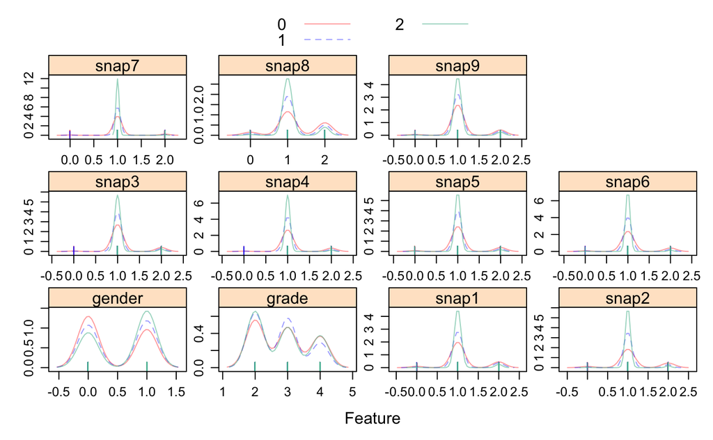

```r
library(caret)
# Feature density plots
library(AppliedPredictiveModeling)
transparentTheme(trans = 0.4)
# plt <- featurePlot(x = E[, 1:11],
featurePlot(x = E[, 1:11],
            y = E$averBinnedF,
            plot = "density",
            scales = list(x = list(relation="free"),
                          y = list(relation="free")),
            pch = "|",
            adjust = 1.5,
            layout = c(4,3),
            ## Add a key at the top
            auto.key = list(columns = 2))
```

```r
# plot(plt)
```

```r
# Functions and Datasets from J. Fox and S. Weisberg, An R Companion to Applied Regression,
# Second Edition, Sage, 2011.
library(car)
# Keep 75 (70) % of the observations for training the classifier,
# and 25 (30) % of the sample for performance evaluation (e.g. confusion matrix)
set.seed(998)
trainIndex <- createDataPartition(E$averBinnedF, p=.75, list=F)
# trainIndex <- createDataPartition(data$class, p=.70, list=F)
E.train <- E[trainIndex, ]
E.test <- E[-trainIndex, ]
# Check the random sample used for training
head(trainIndex)
```

```
     Resample1
[1,]         2
[2,]         3
[3,]         4
[4,]         5
[5,]         6
[6,]         7
```

#### Using an alternative implementation of MLR - mlogit

```r
library(mlogit)
# We need to modify the data so that the multinomial logistic regression
# function can process it. To do this, we need to expand the outcome variable
# (y) much like we would for dummy coding a categorical variable for
# inclusion in standard multiple regression.
head(E)
```

|  | gender | grade | snap1 | snap2 | snap3 | snap4 | snap5 | snap6 | snap7 | snap8 | snap9 | averBinnedF |
| --- | --- | --- | --- | --- | --- | --- | --- | --- | --- | --- | --- | --- |
| 1 | 1 | 2 | 1 | 1 | 1 | 1 | 1 | 1 | 1 | 1 | 1 | 2 |
| 2 | 1 | 2 | 1 | 1 | 2 | 1 | 1 | 1 | 1 | 1 | 1 | 0 |
| 3 | 1 | 2 | 1 | 1 | 1 | 1 | 1 | 1 | 1 | 1 | 1 | 1 |
| 4 | 1 | 2 | 1 | 1 | 1 | 1 | 1 | 1 | 1 | 1 | 1 | 1 |
| 5 | 1 | 2 | 1 | 1 | 1 | 1 | 1 | 1 | 1 | 1 | 1 | 1 |
| 6 | 1 | 2 | 1 | 1 | 1 | 1 | 1 | 1 | 1 | 1 | 1 | 1 |

```r
E2 <- mlogit.data(E, varying=NULL, choice="averBinnedF", shape="wide")
head(E2)
```

|  | gender | grade | snap1 | snap2 | snap3 | snap4 | snap5 | snap6 | snap7 | snap8 | snap9 | averBinnedF | chid | alt |
| --- | --- | --- | --- | --- | --- | --- | --- | --- | --- | --- | --- | --- | --- | --- |
| 1.0 | 1 | 2 | 1 | 1 | 1 | 1 | 1 | 1 | 1 | 1 | 1 | FALSE | 1 | 0 |
| 1.1 | 1 | 2 | 1 | 1 | 1 | 1 | 1 | 1 | 1 | 1 | 1 | FALSE | 1 | 1 |
| 1.2 | 1 | 2 | 1 | 1 | 1 | 1 | 1 | 1 | 1 | 1 | 1 | TRUE | 1 | 2 |
| 2.0 | 1 | 2 | 1 | 1 | 2 | 1 | 1 | 1 | 1 | 1 | 1 | TRUE | 2 | 0 |
| 2.1 | 1 | 2 | 1 | 1 | 2 | 1 | 1 | 1 | 1 | 1 | 1 | FALSE | 2 | 1 |
| 2.2 | 1 | 2 | 1 | 1 | 2 | 1 | 1 | 1 | 1 | 1 | 1 | FALSE | 2 | 2 |

```r
# Now we can proceed with the multinomial logistic regression analysis using
# the ‘mlogit’ function and the ubiquitous ‘summary’ function of the results.
# Note that the reference category is specified as “high” (2, where the levels are 0,1,2).
mlogit.E.1 <- mlogit(averBinnedF ~ 1 | gender+grade +
                    snap1+snap2+snap3+snap4+snap5+snap6+snap7+snap8+snap9,
                    data = E2,
                    reflevel="2")    # reflevel = "high")
mlogit.E.1
```

```
Call:
mlogit(formula = averBinnedF ~ 1 | gender + grade + snap1 + snap2 +     snap3 + snap4 + snap5 + snap6 + snap7 + snap8 + snap9, data = E2,     reflevel = "2", method = "nr", print.level = 0)

Coefficients:
0:(intercept)  1:(intercept)       0:gender       1:gender        0:grade        1:grade        0:snap1
   -3.5762832     -1.2504855     -0.6279175     -0.3316803      0.1155375     -0.0507424      0.3199509
      1:snap1        0:snap2        1:snap2        0:snap3        1:snap3        0:snap4        1:snap4
    0.3166373      0.4878504      0.1794344      0.2741341      0.1132292      0.4929393     -0.0053596
      0:snap5        1:snap5        0:snap6        1:snap6        0:snap7        1:snap7        0:snap8
    0.1919803      0.2016123      0.6182390      0.1536896      0.3621641      0.1969086      0.2414858
      1:snap8        0:snap9        1:snap9
    0.1413410      0.3312066      0.2231962
```

```r
summary(mlogit.E.1)
```

```
Call:
mlogit(formula = averBinnedF ~ 1 | gender + grade + snap1 + snap2 +
    snap3 + snap4 + snap5 + snap6 + snap7 + snap8 + snap9, data = E2,
    reflevel = "2", method = "nr", print.level = 0)

Frequencies of alternatives:
      2       0       1
0.33375 0.32499 0.34126

nr method
4 iterations, 0h:0m:0s
g'(-H)^-1g = 4.4E-07
gradient close to zero

Coefficients :
                Estimate Std. Error t-value  Pr(>|t|)
0:(intercept) -3.5762832  0.5182386 -6.9008 5.169e-12 ***
1:(intercept) -1.2504855  0.5251412 -2.3812  0.017255 *
0:gender      -0.6279175  0.1064526 -5.8986 3.667e-09 ***
1:gender      -0.3316803  0.1026967 -3.2297  0.001239 **
0:grade        0.1155375  0.0660255  1.7499  0.080137 .
1:grade       -0.0507424  0.0640126 -0.7927  0.427956
0:snap1        0.3199509  0.1648061  1.9414  0.052212 .
1:snap1        0.3166373  0.1666324  1.9002  0.057405 .
0:snap2        0.4878504  0.1901667  2.5654  0.010306 *
1:snap2        0.1794344  0.1988692  0.9023  0.366912
0:snap3        0.2741341  0.2167938  1.2645  0.206053
1:snap3        0.1132292  0.2217005  0.5107  0.609540
0:snap4        0.4929393  0.2439380  2.0208  0.043305 *
1:snap4       -0.0053596  0.2554147 -0.0210  0.983259
0:snap5        0.1919803  0.2222726  0.8637  0.387744
1:snap5        0.2016123  0.2286109  0.8819  0.377830
0:snap6        0.6182390  0.2195761  2.8156  0.004869 **
1:snap6        0.1536896  0.2320393  0.6623  0.507751
0:snap7        0.3621641  0.3329030  1.0879  0.276641
1:snap7        0.1969086  0.3376685  0.5831  0.559798
0:snap8        0.2414858  0.1242813  1.9431  0.052009 .
1:snap8        0.1413410  0.1262303  1.1197  0.262838
0:snap9        0.3312066  0.1888650  1.7537  0.079487 .
1:snap9        0.2231962  0.1904452  1.1720  0.241209
---
Signif. codes:  0 ‘***’ 0.001 ‘**’ 0.01 ‘*’ 0.05 ‘.’ 0.1 ‘ ’ 1

Log-Likelihood: -2547.8
McFadden R^2:  0.032332
Likelihood ratio test : chisq = 170.25 (p.value = < 2.22e-16)
```

```r
b <- exp(coef(mlogit.E.1))
b
```

```
0:(intercept) 1:(intercept)      0:gender      1:gender       0:grade       1:grade       0:snap1
    0.0279795     0.2863657     0.5337021     0.7177167     1.1224766     0.9505235     1.3770601
      1:snap1       0:snap2       1:snap2       0:snap3       1:snap3       0:snap4       1:snap4
    1.3725047     1.6288112     1.1965404     1.3153911     1.1198886     1.6371212     0.9946548
      0:snap5       1:snap5       0:snap6       1:snap6       0:snap7       1:snap7       0:snap8
    1.2116467     1.2233737     1.8556573     1.1661289     1.4364347     1.2176328     1.2731394
      1:snap8       0:snap9       1:snap9
    1.1518174     1.3926475     1.2500658
attr(,"fixed")
0:(intercept) 1:(intercept)      0:gender      1:gender       0:grade       1:grade       0:snap1
        FALSE         FALSE         FALSE         FALSE         FALSE         FALSE         FALSE
      1:snap1       0:snap2       1:snap2       0:snap3       1:snap3       0:snap4       1:snap4
        FALSE         FALSE         FALSE         FALSE         FALSE         FALSE         FALSE
      0:snap5       1:snap5       0:snap6       1:snap6       0:snap7       1:snap7       0:snap8
        FALSE         FALSE         FALSE         FALSE         FALSE         FALSE         FALSE
      1:snap8       0:snap9       1:snap9
        FALSE         FALSE         FALSE
```

```r
summary(b)
```

```
   Min. 1st Qu.  Median    Mean 3rd Qu.    Max.
0.02798 1.08900 1.21500 1.14400 1.37400 1.85600
```

```r
# https://www.r-bloggers.com/how-to-get-the-frequency-table-of-a-categorical-variable-as-a-data-frame-in-r/
ci <- confint(mlogit.E.1, level=0.95)
print(ci)
```

```
                     2.5 %      97.5 %
0:(intercept) -4.592012197 -2.56055415
1:(intercept) -2.279743372 -0.22122762
0:gender      -0.836560838 -0.41927415
1:gender      -0.532962137 -0.13039853
0:grade       -0.013870022  0.24494509
1:grade       -0.176204666  0.07471996
0:snap1       -0.003063148  0.64296487
1:snap1       -0.009956100  0.64323078
0:snap2        0.115130551  0.86057030
1:snap2       -0.210342192  0.56921090
0:snap3       -0.150773914  0.69904202
1:snap3       -0.321295736  0.54775408
0:snap4        0.014829613  0.97104907
1:snap4       -0.505963281  0.49524413
0:snap5       -0.243666042  0.62762666
1:snap5       -0.246456770  0.64968145
0:snap6        0.187877786  1.04860020
1:snap6       -0.301099064  0.60847824
0:snap7       -0.290313808  1.01464206
1:snap7       -0.464909544  0.85872683
0:snap8       -0.002101031  0.48507262
1:snap8       -0.106065839  0.38874790
0:snap9       -0.038962061  0.70137524
1:snap9       -0.150069648  0.59646200
```

#### How to plot ROC curves in multiclass classification?

http://stats.stackexchange.com/questions/2151/how-to-plot-roc-curves-in-multiclass-classification install.packages(“pROC”) I recently found this pROC package in R which plots a multiclass ROC using the technique specified by Hand and Till (2001). You can use the multiclass.roc function.

### Example from UCLA Statistical Consulting Group

#### R Data Analysis Examples: Multinomial Logistic Regression

[mlogit](http://www.ats.ucla.edu/stat/r/dae/mlogit.htm)

Multinomial logistic regression is used to model nominal outcome variables, in which the log odds of the outcomes are modeled as a linear combination of the predictor variables.

This page uses the following packages. Make sure that you can load them before trying to run the examples on this page. If you do not have a package installed, run: install.packages(“packagename”), or if you see the version is out of date, run: update.packages().

```r
library(foreign)
library(nnet)
library(ggplot2)
library(reshape2)
```

*Please note:* The purpose of this page is to show how to use various data analysis commands. It does not cover all aspects of the research process which researchers are expected to do. In particular, it does not cover data cleaning and checking, verification of assumptions, model diagnostics or potential follow-up analyses.

#### Examples of multinomial logistic regression

*Example 1.* People’s occupational choices might be influenced by their parents’ occupations and their own education level. We can study the relationship of one’s occupation choice with education level and father’s occupation. The occupational choices will be the outcome variable which consists of categories of occupations.

*Example 2*. A biologist may be interested in food choices that alligators make. Adult alligators might have different preferences from young ones. The outcome variable here will be the types of food, and the predictor variables might be size of the alligators and other environmental variables.

*Example 3.* Entering high school students make program choices among general program, vocational program and academic program. Their choice might be modeled using their writing score and their social economic status.

#### Description of the data

```r
ml <- read.dta("http://www.ats.ucla.edu/stat/data/hsbdemo.dta")
```

The data set contains variables on 200 students. The outcome variable is prog, program type. The predictor variables are social economic status, ses, a three-level categorical variable and writing score, write, a continuous variable. Let’s start with getting some descriptive statistics of the variables of interest.

```r
with(ml, table(ses, prog))
```

```
        prog
ses      general academic vocation
  low         16       19       12
  middle      20       44       31
  high         9       42        7
```

```r
with(ml, do.call(rbind, tapply(write, prog,
  function(x) c(M = mean(x), SD = sd(x)))))
```

```
                M       SD
general  51.33333 9.397775
academic 56.25714 7.943343
vocation 46.76000 9.318754
```

#### Analysis methods you might consider

- Multinomial logistic regression, the focus of this page.
- Multinomial probit regression, similar to multinomial logistic regression with independent normal error terms.
- Multiple-group discriminant function analysis. A multivariate method for multinomial outcome variables
- Multiple logistic regression analyses, one for each pair of outcomes: One problem with this approach is that each analysis is potentially run on a different sample. The other problem is that without constraining the logistic models, we can end up with the probability of choosing all possible outcome categories greater than 1.
- Collapsing number of categories to two and then doing a logistic regression: This approach suffers from loss of information and changes the original research questions to very different ones.
- Ordinal logistic regression: If the outcome variable is truly ordered and if it also satisfies the assumption of proportional odds, then switching to ordinal logistic regression will make the model more parsimonious.
- Alternative-specific multinomial probit regression, which allows different error structures therefore allows to relax the IIA assumption. This requires that the data structure be choice-specific.
- Nested logit model, another way to relax the IIA assumption, also requires the data structure be choice-specific.

#### Multinomial logistic regression

Below we use the multinom function from the nnet package to estimate a multinomial logistic regression model. There are other functions in other R packages capable of multinomial regression. We chose the multinom function because it does not require the data to be reshaped (as the mlogit package does) and to mirror the example code found in Hilbe’s Logistic Regression Models.

Before running our model it is important to choose a refernce group for our outcome. We can choose the level of our outcome that we wish to use as our baseline and specify this in the relevel function. Then, we run our model using multinom. The multinom package does not include p-value calculation for the regression coefficients, so we calculate p-values using Wald tests (here z-tests).

```r
ml$prog2 <- relevel(ml$prog, ref = "academic")
test <- multinom(prog2 ~ ses + write, data = ml)
```

```r
summary(test)
```

```
Call:
multinom(formula = prog2 ~ ses + write, data = ml)

Coefficients:
         (Intercept)  sesmiddle    seshigh      write
general     2.852198 -0.5332810 -1.1628226 -0.0579287
vocation    5.218260  0.2913859 -0.9826649 -0.1136037

Std. Errors:
         (Intercept) sesmiddle   seshigh      write
general     1.166441 0.4437323 0.5142196 0.02141097
vocation    1.163552 0.4763739 0.5955665 0.02221996

Residual Deviance: 359.9635
AIC: 375.9635
```

```r
z <- summary(test)$coefficients/summary(test)$standard.errors
print(z)
```

```
         (Intercept)  sesmiddle   seshigh     write
general     2.445214 -1.2018081 -2.261334 -2.705562
vocation    4.484769  0.6116747 -1.649967 -5.112689
```

```r
#2-tailed z test
p <- (1 - pnorm(abs(z), 0, 1))*2
print(p)
```

```
          (Intercept) sesmiddle    seshigh        write
general  0.0144766100 0.2294379 0.02373856 6.818902e-03
vocation 0.0000072993 0.5407530 0.09894976 3.176045e-07
```

The ratio of the probability of choosing one outcome category over the probability of choosing the baseline category is often referred as relative risk (and it is also sometimes referred as odds as we have just used to described the regression parameters above). The relative risk is the right-hand side linear equation exponentiated, leading to the fact that the exponentiated regression coefficients are relative risk ratios for a unit change in the predictor variable. We can exponentiate the coefficients from our model to see these risk ratios.

```r
## extract the coefficients from the model and exponentiate
exp(coef(test))
```

```
         (Intercept) sesmiddle   seshigh     write
general     17.32582 0.5866769 0.3126026 0.9437172
vocation   184.61262 1.3382809 0.3743123 0.8926116
```

You can also use predicted probabilities to help you understand the model. You can calculate predicted probabilities for each of our outcome levels using the fitted function. We can start by generating the predicted probabilities for the observations in our dataset and viewing the first few rows

```r
head(pp <- fitted(test))
```

```
   academic   general  vocation
1 0.1482764 0.3382454 0.5134781
2 0.1202017 0.1806283 0.6991700
3 0.4186747 0.2368082 0.3445171
4 0.1726885 0.3508384 0.4764731
5 0.1001231 0.1689374 0.7309395
6 0.3533566 0.2377976 0.4088458
```

Next, if we want to examine the changes in predicted probability associated with one of our two variables, we can create small datasets varying one variable while holding the other constant. We will first do this holding write at its mean and examining the predicted probabilities for each level of ses.

```r
dses <- data.frame(ses = c("low", "middle", "high"), write = mean(ml$write))
predict(test, newdata = dses, "probs")
```

```
   academic   general  vocation
1 0.4396845 0.3581917 0.2021238
2 0.4777488 0.2283353 0.2939159
3 0.7009007 0.1784939 0.1206054
```

Another way to understand the model using the predicted probabilities is to look at the averaged predicted probabilities for different values of the continuous predictor variable write within each level of *ses*.

```r
#dwrite <- data.frame(ses = rep(c("low", "middle", "high"), each = 41), write = rep(c(30:70), 3)
# store the predicted probabilities for each value of ses and write
pp.write <- cbind(dwrite, predict(test, newdata = dwrite, type = "probs", se = TRUE))

## calculate the mean probabilities within each level of ses
by(pp.write[, 3:5], pp.write$ses, colMeans)
```

[output not shown]

Sometimes, a couple of plots can convey a good deal amount of information. Using the predictions we generated for the pp.write object above, we can plot the predicted probabilities against the writing score by the level of ses for different levels of the outcome variable.

```r
## melt data set to long for ggplot2
lpp <- melt(pp.write, id.vars = c("ses", "write"), value.name = "probability")
head(lpp) # view first few rows
```

[output not shown]

```r
## plot predicted probabilities across write values for
## each level of ses facetted by program type
ggplot(lpp, aes(x = write, y = probability, colour = ses)) +
  geom_line() +
  facet_grid(variable ~ ., scales="free")
```

[output not shown]

#### Things to consider

- The Independence of Irrelevant Alternatives (IIA) assumption: Roughly, the IIA assumption means that adding or deleting alternative outcome categories does not affect the odds among the remaining outcomes. There are alternative modeling methods, such as alternative-specific multinomial probit model, or nested logit model to relax the IIA assumption.
- Diagnostics and model fit: Unlike logistic regression where there are many statistics for performing model diagnostics, it is not as straightforward to do diagnostics with multinomial logistic regression models. For the purpose of detecting outliers or influential data points, one can run separate logit models and use the diagnostics tools on each model.
- Sample size: Multinomial regression uses a maximum likelihood estimation method, it requires a large sample size. It also uses multiple equations. This implies that it requires an even larger sample size than ordinal or binary logistic regression.
- Complete or quasi-complete separation: Complete separation means that the outcome variable separate a predictor variable completely, leading perfect prediction by the predictor variable.
- Perfect prediction means that only one value of a predictor variable is associated with only one value of the response variable. But you can tell from the output of the regression coefficients that something is wrong. You can then do a two-way tabulation of the outcome variable with the problematic variable to confirm this and then rerun the model without the problematic variable.
- Empty cells or small cells: You should check for empty or small cells by doing a cross-tabulation between categorical predictors and the outcome variable. If a cell has very few cases (a small cell), the model may become unstable or it might not even run at all.

```r
# The function trainControl can be used to specifiy the type of resampling in the training set
fitControl <- trainControl(   ## 10-fold CV [cross validation]
  method = "repeatedcv",
  number = 10,
  ## repeated ten times
  repeats = 10)

# Preprocessing (normalization) of training data
# Check: https://github.com/topepo/caret/issues/160
pp.E.train <- preProcess(E.train, method = c("center", "scale"))
pp.E.train <- predict.preProcess(pp.E.train, E.train)
# Preprocessing (normalization) of test data
pp.E.test <- preProcess(E.test, method = c("center", "scale"))
pp.E.test <- predict.preProcess(pp.E.test, E.test)
head(pp.E.train)
head(E.train)
head(pp.E.test)
head(E.test)
```

[output not shown]

```r
# Neural Network classifier  cf. help(nnet)
# method = 'nnet'
# Type: Classification, Regression
# Tuning Parameters: size (#Hidden Units), decay (Weight Decay)

# For these caret models, train can automatically create a grid of tuning parameters.
# By default, if p is the number of tuning parameters, the grid size is 3^p.
# For nnet we explore
my.nnet.grid <- expand.grid(.decay = c(0.05, 0.10, 0.15, 0.20, 0.25), .size = c(3, 5, 7, 9))

E.nnet.fit <- train(averBinnedF ~. , data = E.train,
                       method = "nnet",
                       maxit = 1000,
                       trControl = fitControl,
                       tuneGrid = my.nnet.grid,
                       trace = FALSE)

print(E.nnet.fit$finalModel$problemType)
print(E.nnet.fit$finalModel$n)
print(E.nnet.fit$finalModel$call)
print(E.nnet.fit$finalModel)
print(E.nnet.fit)

trellis.par.set(caretTheme())
plot(E.nnet.fit)
```

[output not shown]

```r
# Call predict on the fitted object using the test data set
E.test.nnet.predict <- predict(E.nnet.fit, newdata = E.test, na.action = na.omit, verbose = TRUE)
print(summary(as.data.frame(E.test.nnet.predict)))
print(summary(as.data.frame(E.test$averBinnedF)))

# Assess confusion matrix
cm.nnet.fit.E.test <- confusionMatrix(E.test.nnet.predict, E.test$averBinnedF)
print(cm.nnet.fit.E.test)
```

[output not shown]

```r
library(plyr)
#mapvalues(E$averBinnedF, from = c("0", "1", "2"), to = c("L", "M", "H"))
#revalue(E$averBinnedF, c("0"="L", "1"="M", "2"="H"))
levels(E$averBinnedF)[levels(E$averBinnedF)=="0"] <- "L"
levels(E$averBinnedF)[levels(E$averBinnedF)=="1"] <- "M"
levels(E$averBinnedF)[levels(E$averBinnedF)=="2"] <- "H"

set.seed(998)
trainIndex <- createDataPartition(E$averBinnedF, p=.75, list=F)
# trainIndex <- createDataPartition(data$class, p=.70, list=F)
E.train <- E[trainIndex, ]
E.test <- E[-trainIndex, ]
```

```r
fitControl <- trainControl(   ## 10-fold CV [cross validation]
  method = "repeatedcv",
  number = 10,
  ## repeated ten times
  repeats = 10,
  classProbs = TRUE)
```

```r
svmFit <- train(averBinnedF ~ . , data = E.train,
                 method = "svmRadial",
                 trControl = fitControl,
                 tuneLength = 8,
                 metric = "ROC")
svmFit
```

[output not shown]

```r
# Call predict on the fitted object using the test data set
E.test.svm.predict <- predict(svmFit, newdata = E.test, na.action = na.omit, verbose = TRUE)
print(summary(as.data.frame(E.test.svm.predict)))
print(summary(as.data.frame(E.test$averBinnedF)))

# Assess confusion matrix
cm.svm.fit.E.test <- confusionMatrix(E.test.svm.predict, E.test$averBinnedF)
print(cm.svm.fit.E.test)
```

[output not shown]